# DATA 300 3 Homework 2 Solution

Aadarsha Gopala Reddy

September 27, 2022

# 1. Data Import

Load any packages that you will use to complete the assignment. Import `carbon_emissions.csv` as an object in R.

> `library()` Loads any packages.

> `read.csv()` Reads the csv file.

```r
library(tidyverse)
carbon_emissions <- read_csv("carbon_emissions.csv")
```

# 2. Fitting a Bivariate Model

Fit a linear model where the outcome is carbon emissions per capita and the predictor is GDP per capita. Apply any data transformations you believe are appropriate. (You might investigate whether data transformations are appropriate by visualizing the data or some other approach.)

```r
carbon_emissions <- carbon_emissions %>%
  mutate(
    co2_per_capita = log(co2_per_capita),
    gdp_per_capita = log(gdp_per_capita),
    energy_per_capita = log(energy_per_capita + 0.001) #+0.001 to avoid log(0)
  )

# na.rm = TRUE to remove NA values and prevent outputs from being NA
# create min, max, and mean values for gdp and energy_per_capita
carbon_emissions %>%
  summarise(
    min_gdp = min(gdp_per_capita, na.rm = TRUE),
    max_gdp = max(gdp_per_capita, na.rm = TRUE),
    mean_gdp = mean(gdp_per_capita, na.rm = TRUE),
    min_energy = min(energy_per_capita, na.rm = TRUE),
    max_energy = max(energy_per_capita, na.rm = TRUE),
    mean_energy = mean(energy_per_capita, na.rm = TRUE)
  )
```

| min_gdp | max_gdp | mean_gdp | min_energy | max_energy | mean_energy |
| --- | --- | --- | --- | --- | --- |
| 5.948514 | 11.89414 | 8.825282 | -6.907755 | 12.64014 | 8.978697 |

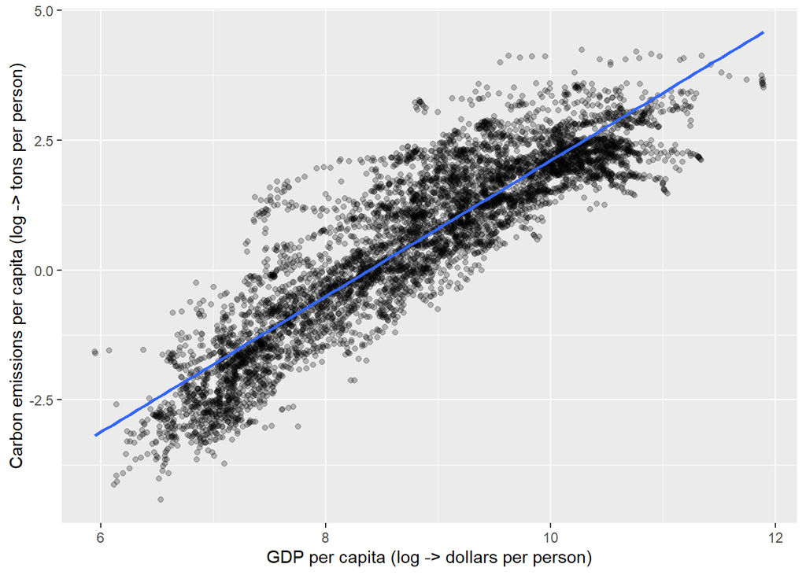

```r
# plot a chart with the points having an alpha of 0.5
ggplot(
  carbon_emissions,
  aes(x = gdp_per_capita, y = co2_per_capita)
) +
  geom_point(alpha = 0.25) +
  geom_smooth(method = "lm", se = FALSE) +
  labs(
    x = "GDP per capita (log -> dollars per person)",
    y = "Carbon emissions per capita (log -> tons per person)"
  )
```

```r
# fit a linear model
model <- lm(co2_per_capita ~ gdp_per_capita, data = carbon_emissions)

summary(model)
```

```
##
## Call:
## lm(formula = co2_per_capita ~ gdp_per_capita, data = carbon_emissions)
##
## Residuals:
##      Min       1Q   Median       3Q      Max
## -2.19079 -0.49833 -0.09689  0.40296  2.77028
##
## Coefficients:
##                  Estimate Std. Error t value Pr(>|t|)
## (Intercept)    -10.953202   0.071300  -153.6   <2e-16 ***
## gdp_per_capita   1.305839   0.008013   163.0   <2e-16 ***
## ---
## Signif. codes:  0 '***' 0.001 '**' 0.01 '*' 0.05 '.' 0.1 ' ' 1
##
## Residual standard error: 0.7511 on 6346 degrees of freedom
##   (2612 observations deleted due to missingness)
## Multiple R-squared:  0.8071, Adjusted R-squared:  0.8071
## F-statistic: 2.656e+04 on 1 and 6346 DF,  p-value: < 2.2e-16
```

```r
# plot(model)
```

# 3. Interpreting The Bivariate Model

Interpret the output from the bivariate model.

- Is the relationship between GDP and carbon emissions positive or negative? What is the magnitude of the association? (How much should we expect carbon emissions to change when GDP increases?)

> *Since the p-value is <2e-16, the coefficient estimate is statistically significant at the .05 level.*
- How well does the model fit? (You might check metrics like the R-squared value or use visualization to answer this question.)

> *The R-squared value is 0.8071, which means that 80.71% of the variation in carbon emissions is explained by the model. The model fits well.*

# 4. Fitting a Multivariate Model

Fit a linear model where the outcome is carbon emissions per capita. This time, include GDP per capita and at least one other predictor variable of your choosing. Again, apply any data transformations that you believe are appropriate.

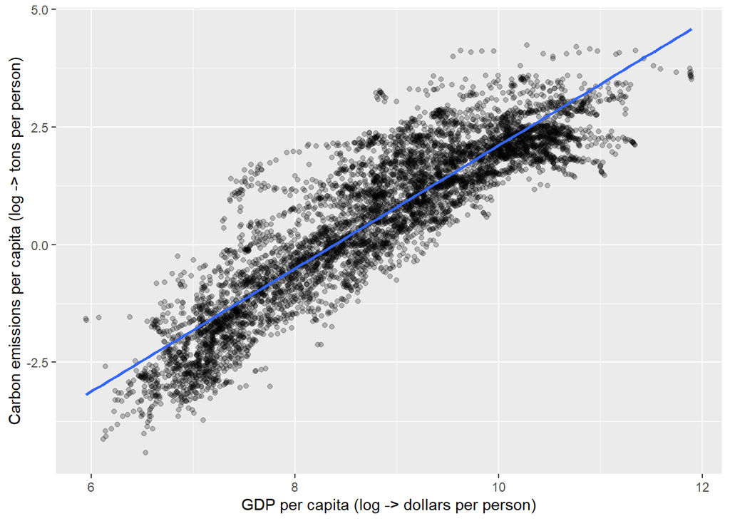

```r
ggplot(
  carbon_emissions,
  aes(x = gdp_per_capita, y = co2_per_capita)
) +
  geom_point(alpha = 0.25) +
  geom_smooth(method = "lm", se = FALSE) +
  labs(
    x = "GDP per capita (log -> dollars per person)",
    y = "Carbon emissions per capita (log -> tons per person)"
  )
```

```r
# fit a linear model
model2 <- lm(
  co2_per_capita ~ gdp_per_capita + energy_per_capita,
  data = carbon_emissions[]
)

summary(model)
```

[output not shown]

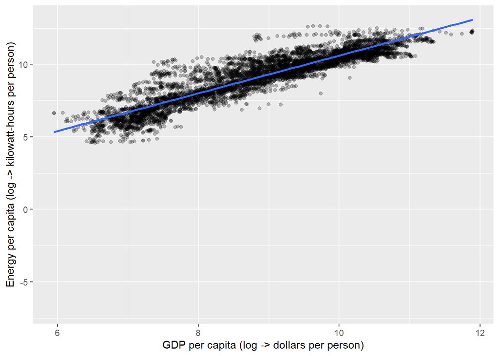

```r
ggplot(
  carbon_emissions,
  aes(x = gdp_per_capita, y = energy_per_capita)
) +
  geom_point(alpha = 0.25) +
  geom_smooth(method = "lm", se = FALSE) +
  labs(
    x = "GDP per capita (log -> dollars per person)",
    y = "Energy per capita (log -> kilowatt-hours per person)"
  )
```

```r
# plot(model2)
```

Justify your choice of predictor variables. Why are the variables you chose appropriate for the model?

> *I chose energy per capita as the other predictor variable because I think it alongwith GDP per capita will explain the variation in carbon emissions per capita. I think this is appropriate because the amount of energy consumed by a nation might explain it’s carbon emissions better. Additionally, the higher a country’s GDP, the higher energy it consumes.*

# 5. Interpreting the Multivariate Model

Interpret the output from the multivariate model.

- Are the relationships between the predictors positive or negative?

# 6. Out-Of-Sample Predictions

Using the multivariate model from the previous question, calculate the predicted values of carbon emissions per capita across the range of GDP per capita. Set all other predictor variables to their mean value for this prediction.

You can generate predictions using manual calculations or by using R’s predict() function. Give at least the predicted values of carbon emission per capita for the maximum, minimum, and mean GDP observed in the dataset.

> `predict()` Generates predictions from a model.

```r
predict(
  model2,
  data.frame(
    gdp_per_capita = c(
      min(carbon_emissions$gdp_per_capita, na.rm = TRUE),
      max(carbon_emissions$gdp_per_capita, na.rm = TRUE),
      mean(carbon_emissions$gdp_per_capita, na.rm = TRUE)
    ),
    energy_per_capita = c(
      min(carbon_emissions$energy_per_capita, na.rm = TRUE),
      max(carbon_emissions$energy_per_capita, na.rm = TRUE),
      mean(carbon_emissions$energy_per_capita, na.rm = TRUE)
    )
  )
)
```

```
##          1          2          3
## -14.108070   4.147957   0.448963
```

# 7. Subset the Data

Today, almost every country in the world has signed an international pledge to lower carbon emissions. This wasn’t always the case. In 1998, a group of world leaders were the first to sign the Kyoto Protocol, an international agreement to limit carbon emissions and combat climate change.

Which countries were most likely to sign the Kyoto Protocol when it was introduced? We will build a model to answer this question. First, subset the dataset to only observations from the year 1998.

```r
carbon_emissions_1998 <- carbon_emissions %>% filter(year == 1998)
```

# 8. Modeling the Decision to Sign the Kyoto Protocol

The variable `kyoto` is a binary variable that records whether a country signed the Kyoto Protocol in the year 1998. Countries with a value of 1 signed the Kyoto Protocol in that year, and countries with a value of 0 did not.

Build a model where the outcome is `kyoto`. Justify your choice of model and your choice of predictor variable(s).

> *I chose a logistic regression model because the outcome is binary. I chose the gdp per capita as the predictor variable because it seems to be the most important predictor of carbon emissions.*

```r
model3 <- glm(
  kyoto ~ gdp_per_capita,
  data = carbon_emissions_1998,
  family = binomial(link = "logit")
)

# plot(model3)
```

# 9. Out-Of-Sample Predictions for the Kyoto Protocol

Choose one predictor variable from the model in the previous question. Calculate the predicted probability that a country signed the Kyoto protocol across the range of that variable. (If there are other variables in your model, set them to their mean value.)

Give at least the predicted probabilities of signing the treaty for the minimum, maximum, and mean values of the variable you chose. (Hint: if using R’s `predict()` function, you may find it helpful to check the help page for predict.glm.)

> `predict.glm()` Generates predictions from a generalized linear model.

```r
predict(
  model3,
  data.frame(
    gdp_per_capita = c(
      min(carbon_emissions$gdp_per_capita, na.rm = TRUE),
      max(carbon_emissions$gdp_per_capita, na.rm = TRUE),
      mean(carbon_emissions$gdp_per_capita, na.rm = TRUE)
    )
  ),
  type = "response"
)
```

```
##          1          2          3
## 0.04275094 0.93542999 0.42284469
```